# Analyze_ab_test_results_notebook

## Analyze A/B Test Results

- Introduction
- Part I - Probability
- Part II - A/B Test
- Part III - Regression

### Introduction

For this project, we will be working to understand the results of an A/B test run by an e-commerce website. The goal is to work through this notebook to help the company understand if they should implement the new page, keep the old page, or perhaps run the experiment longer to make their decision.

#### Part I - Probability

To get started, we should import our libraries.

```python
import pandas as pd
import numpy as np
import random
import matplotlib.pyplot as plt
%matplotlib inline
random.seed(42)
```

`1.` Now, we should read in the `ab_data.csv` data. Store it in `df`.

a. Let's read in the dataset and take a look at the top few rows here:

```python
df = pd.read_csv('ab_data.csv')
df.head()
```

|  | user_id | timestamp | group | landing_page | converted |
| --- | --- | --- | --- | --- | --- |
| 0 | 851104 | 2017-01-21 22:11:48.556739 | control | old_page | 0 |
| 1 | 804228 | 2017-01-12 08:01:45.159739 | control | old_page | 0 |
| 2 | 661590 | 2017-01-11 16:55:06.154213 | treatment | new_page | 0 |
| 3 | 853541 | 2017-01-08 18:28:03.143765 | treatment | new_page | 0 |
| 4 | 864975 | 2017-01-21 01:52:26.210827 | control | old_page | 1 |

b. It would be useful to find the number of rows in the dataset.

```python
df.shape
```

```
(294478, 5)
```

c. The number of unique users in the dataset.

```python
df['user_id'].nunique()
```

```
290584
```

d. The proportion of users converted.

```python
(df.converted == 1).sum()
```

```
35237
```

```python
(df.converted == 0).sum()
```

```
259241
```

```python
# the proportion is 12%
df.converted.mean()
```

```
0.11965919355605512
```

e. The number of times the `new_page` and `treatment` don't match.

```python
# this is the number of how many times new_page and treatment match
(df.query('group == "treatment"')['landing_page'] == 'new_page').sum()
```

```
145311
```

```python
# in orther to find the number of how many times new page and
# treatement do not match, I find out the number of
# how many times does the new_page matches every element
# except treatment
new_page_match = (df.query('group != "treatment"')['landing_page'] == 'new_page').sum()
```

```python
# and as the next step I check how many times treatment
# matches every element of landing page except new_page
treatment_match = (df.query('group == "treatment"')['landing_page'] != 'new_page').sum()
```

```python
# by adding both variables above we get the number of
# how many times new_page and treatment don't match
new_page_match + treatment_match
```

```
3893
```

f. We can check whether any of the rows have missing values.

```python
# there is no missing value in the data
df.info()
```

```
<class 'pandas.core.frame.DataFrame'>
RangeIndex: 294478 entries, 0 to 294477
Data columns (total 5 columns):
user_id         294478 non-null int64
timestamp       294478 non-null object
group           294478 non-null object
landing_page    294478 non-null object
converted       294478 non-null int64
dtypes: int64(2), object(3)
memory usage: 11.2+ MB
```

`2.` For the rows where **treatment** does not match with **new_page** or **control** does not match with **old_page**, we cannot be sure if this row truly received the new or old page.

a. Now we can create a new dataframe which has only treatment group matching new page and control group matching old page.

```python
x = df.query("group == 'treatment' and landing_page == 'new_page'")
y = df.query("group == 'control' and landing_page == 'old_page'")
df2 = x.append(y, ignore_index = True)
```

```python
# Double Check all of the correct rows were removed - this should be 0
df2[((df2['group'] == 'treatment') == (df2['landing_page'] == 'new_page')) == False].shape[0]
```

```
0
```

`3.` By unsing **df2** we can answer following questions.

a. How many unique **user_id**s are in **df2**?

```python
df2.user_id.nunique()
```

```
290584
```

b. There is one **user_id** repeated in **df2**. What is it?

```python
df2.user_id.duplicated().sum()
```

```
1
```

c. What is the row information for the repeat **user_id**?

```python
df2[df2.user_id.duplicated()]
```

[output not shown]

d. Let us remove **one** of the rows with a duplicate **user_id**, but keep the dataframe as **df2**.

```python
df2.drop(2893, inplace=True)
```

`4.` We can use **df2** to answer following questions.

a. What is the probability of an individual converting regardless of the page they receive?

```python
df2.query('converted == 1').shape[0]/ df2.user_id.nunique()
```

[output not shown]

b. Given that an individual was in the `control` group, what is the probability they converted?

```python
df2.query('converted == 1 and group == "control"').shape[0]/df2.query('group == "control"').shape[0]
```

```
0.1203863045004612
```

c. Given that an individual was in the `treatment` group, what is the probability they converted?

```python
df2.query('converted == 1 and group == "treatment"').shape[0]/df2.query('group == "treatment"').shape[0]
```

```
0.11880806551510564
```

d. What is the probability that an individual received the new page?

```python
df2.query('landing_page == "new_page"').shape[0]/df2.user_id.nunique()
```

[output not shown]

```python
df2.query('landing_page == "old_page"').shape[0]/df2.user_id.nunique()
```

```
0.4999397762429323
```

```python
df2.head()
```

|  | user_id | timestamp | group | landing_page | converted |
| --- | --- | --- | --- | --- | --- |
| 0 | 661590 | 2017-01-11 16:55:06.154213 | treatment | new_page | 0 |
| 1 | 853541 | 2017-01-08 18:28:03.143765 | treatment | new_page | 0 |
| 2 | 679687 | 2017-01-19 03:26:46.940749 | treatment | new_page | 1 |
| 3 | 817355 | 2017-01-04 17:58:08.979471 | treatment | new_page | 1 |
| 4 | 839785 | 2017-01-15 18:11:06.610965 | treatment | new_page | 1 |

### Part II - A/B Test

Null Hypothesis (H0): the conversion rate of new page is less or equal to conversion rate of old page. Alternative Hypothesis (H1): the conversion rate of new page is more than conversion rate of old page with 5% (0.05 rate).

So using the data I already have it is not possible to reject the Null Hypothesis.

`2.` Let's assume under the null hypothesis, $p_{new}$ and $p_{old}$ both have "true" success rates equal to the **converted** success rate regardless of page - that is $p_{new}$ and $p_{old}$ are equal. Furthermore, we cam assume they are equal to the **converted** rate in **ab_data.csv** regardless of the page.

We can perform the sampling distribution for the difference in **converted** between the two pages over 10,000 iterations of calculating an estimate from the null.

By using df2 dataframe let's answer to following questions.

a. What is the **conversion rate** for $p_{new}$ under the null?

```python
# since we are assuming that the conversion rate is equal
# for both Pnew and Pold, we can simply calculate the
# conversion mean
pnew = df2.converted.mean()
pnew
```

```
0.11959708724499628
```

b. What is the **conversion rate** for $p_{old}$ under the null?

```python
# in this case the Pold and Pnew are counted with same way
# as their conversion rate is assumed to be equal
pold = df2.converted.mean()
pold
```

```
0.11959708724499628
```

c. What is $n_{new}$, the number of individuals in the treatment group?

```python
# the number of individual can be simply counted with query
# we can use either count() or nunique() to get the number
nnew = df2.query('group == "treatment"').user_id.count()
nnew
```

```
145310
```

d. What is $n_{old}$, the number of individuals in the control group?

```python
nold = df2.query('group == "control"').user_id.nunique()
nold
```

```
145274
```

e. Simulate $n_{new}$ transactions with a conversion rate of $p_{new}$ under the null. Store these $n_{new}$ 1's and 0's in **new_page_converted**.

```python
# to simulate the transaction can either use
# np.random.choice or np.ranom.binomial
new_page_converted = np.random.choice([0,1],size=nnew, p=[1-pnew,pnew])
new_page_converted.mean()
```

```
0.12006744202050788
```

f. Let's simulate $n_{old}$ transactions with a conversion rate of $p_{old}$ under the null. Store these $n_{old}$ 1's and 0's in **old_page_converted**,

```python
old_page_converted = np.random.binomial(1, pold, nold)
old_page_converted.mean()
```

```
0.1204620234866528
```

g. and also find $p_{new}$ - $p_{old}$ for the simulated values from part (e) and (f).

```python
obs_diff = df2.query('group == "treatment"').converted.mean() - df2.query('group == "control"').converted.mean()
obs_diff
```

```
-0.0015782389853555567
```

```python
# for our simulated values we alse need to count
# the average difference of converted new and old pages
sim_diff = new_page_converted.mean() - old_page_converted.mean()
sim_diff
```

```
-0.00039458146614491929
```

h. As discussed above we want to create 10,000 $p_{new}$ - $p_{old}$ values using the same simulation process we used in parts (a) through (g) above. Store all 10,000 values in a NumPy array called **p_diffs**.

```python
p_diffs = []
size = df2.shape[0]
for _ in range(10000):
    new_page_converted = np.random.choice([0,1],size=nnew, p=[1-pnew,pnew])
    old_page_converted = np.random.binomial(1, pold, nold)
    sim_diff = new_page_converted.mean() - old_page_converted.mean()
    p_diffs.append(sim_diff)
```

```python
# we need to convert our p_diffs to numpy array
p_diffs = np.array(p_diffs)
```

i. In order to have a clearer picture let's plot a histogram of the **p_diffs**.

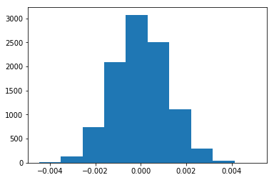

```python
plt.hist(p_diffs);
```

j. What proportion of the **p_diffs** are greater than the actual difference observed in **ab_data.csv**?

```python
# now we can count our p_value
(p_diffs > obs_diff).mean()
```

```
0.90610000000000002
```

l. We could also use a built-in to achieve similar results. Though using the built-in might be easier to code, the above portions are a walkthrough of the ideas that are critical to correctly thinking about statistical significance. We can fill in the below to calculate the number of conversions for each page, as well as the number of individuals who received each page. Let `n_old` and `n_new` refer the the number of rows associated with the old page and new pages, respectively.

```python
import statsmodels.api as sm

convert_old = df2.query('landing_page == "old_page" and converted == 1').converted.count()
convert_new = df2.query('landing_page == "new_page" and converted == 1').converted.count()
n_old = df2.query('landing_page == "old_page"').group.count()
n_new = df2.query('landing_page == "new_page"').group.count()
```

m. Now we use `stats.proportions_ztest` to compute our test statistic and p-value.

```python
zvalue_pvalue = sm.stats.proportions_ztest([convert_old, convert_new], [n_old, n_new], alternative = 'smaller')
zvalue_pvalue
```

```
(1.3109241984234394, 0.90505831275902449)
```

### Part III - A regression approach

`1.` In this final part, we will see that the result we achieved in the A/B test in Part II above can also be achieved by performing regression.

a. Since we deal with categorical variables we can choose Logistic regression for our analysis.

b. The goal is to use **statsmodels** to fit the regression model we specified in part **a.** to see if there is a significant difference in conversion based on which page a customer receives. However, we first need to create in df2 a column for the intercept, and create a dummy variable column for which page each user received. Add an **intercept** column, as well as an **ab_page** column, which is 1 when an individual receives the **treatment** and 0 if **control**.

```python
df2['intercept'] = 1
df2[['group_2','ab_page']]=pd.get_dummies(df2['group'])
```

```python
df2 = df2.drop('group_2', axis = 1)
```

```python
df2.head()
```

|  | user_id | timestamp | group | landing_page | converted | intercept | ab_page |
| --- | --- | --- | --- | --- | --- | --- | --- |
| 0 | 661590 | 2017-01-11 16:55:06.154213 | treatment | new_page | 0 | 1 | 1 |
| 1 | 853541 | 2017-01-08 18:28:03.143765 | treatment | new_page | 0 | 1 | 1 |
| 2 | 679687 | 2017-01-19 03:26:46.940749 | treatment | new_page | 1 | 1 | 1 |
| 3 | 817355 | 2017-01-04 17:58:08.979471 | treatment | new_page | 1 | 1 | 1 |
| 4 | 839785 | 2017-01-15 18:11:06.610965 | treatment | new_page | 1 | 1 | 1 |

c. We can **statsmodels** to instantiate the regression model on the two columns we created in part b., then fit the model using the two columns we created in part **b.** to predict whether or not an individual converts.

```python
logit_mod = sm.Logit(df2['converted'], df2[['intercept', 'ab_page']])
results = logit_mod.fit()
results.summary2()
```

```
Optimization terminated successfully.
         Current function value: 0.366118
         Iterations 6
```

| Model: | Logit | No. Iterations: | 6.0000 |
| --- | --- | --- | --- |
| Dependent Variable: | converted | Pseudo R-squared: | 0.000 |
| Date: | 2021-02-21 16:47 | AIC: | 212780.3502 |
| No. Observations: | 290584 | BIC: | 212801.5095 |
| Df Model: | 1 | Log-Likelihood: | -1.0639e+05 |
| Df Residuals: | 290582 | LL-Null: | -1.0639e+05 |
| Converged: | 1.0000 | Scale: | 1.0000 |

|  | Coef. | Std.Err. | z | P>\|z\| | [0.025 | 0.975] |
| --- | --- | --- | --- | --- | --- | --- |
| intercept | -1.9888 | 0.0081 | -246.6690 | 0.0000 | -2.0046 | -1.9730 |
| ab_page | -0.0150 | 0.0114 | -1.3109 | 0.1899 | -0.0374 | 0.0074 |

d. We can see in our statistical summary that we have a p-value of 0.1899.

There is a difference between hypothesis forumulas with regression summary and the way we did in part II. The logistic regression use a two-tailed test for the coefficient of variable. So our  
Hypothesis 0 (H0) in regression says coef (coefficient) of ab_page = 0;  
Hypothesis 1 (H1) in regression says coef (coefficient) of ab_page != 0 (not equal).

f. We can add other variables to our initial regression model to see their influence on convertion. There may be other factors which could have influence on convertion which were not considered because of a random distribution of assignment to control and treatment groups. Adding new categories to our regression model has control purpose and will not have a negative impact on results.

g. Now along with testing if the conversion rate changes for different pages, we can also add an effect based on which country a user lives in. We will need to read in the **countries.csv** dataset and merge together our datasets on the appropriate rows.

```python
df3 = pd.read_csv("countries.csv")
df3.head()
```

|  | user_id | country |
| --- | --- | --- |
| 0 | 834778 | UK |
| 1 | 928468 | US |
| 2 | 822059 | UK |
| 3 | 711597 | UK |
| 4 | 710616 | UK |

```python
df2 = df2.join(df3, lsuffix = '_country')
```

```python
df2.head()
```

|  | user_id_country | timestamp | group | landing_page | converted | intercept | ab_page | user_id | country |
| --- | --- | --- | --- | --- | --- | --- | --- | --- | --- |
| 0 | 661590 | 2017-01-11 16:55:06.154213 | treatment | new_page | 0 | 1 | 1 | 834778.0 | UK |
| 1 | 853541 | 2017-01-08 18:28:03.143765 | treatment | new_page | 0 | 1 | 1 | 928468.0 | US |
| 2 | 679687 | 2017-01-19 03:26:46.940749 | treatment | new_page | 1 | 1 | 1 | 822059.0 | UK |
| 3 | 817355 | 2017-01-04 17:58:08.979471 | treatment | new_page | 1 | 1 | 1 | 711597.0 | UK |
| 4 | 839785 | 2017-01-15 18:11:06.610965 | treatment | new_page | 1 | 1 | 1 | 710616.0 | UK |

```python
df2[['CA','UK','US']] = pd.get_dummies(df2['country'])
```

```python
df2.drop('CA', axis=1, inplace=True)
```

```python
df2.head()
```

|  | user_id_country | timestamp | group | landing_page | converted | intercept | ab_page | user_id | country | UK | US |
| --- | --- | --- | --- | --- | --- | --- | --- | --- | --- | --- | --- |
| 0 | 661590 | 2017-01-11 16:55:06.154213 | treatment | new_page | 0 | 1 | 1 | 834778.0 | UK | 1 | 0 |
| 1 | 853541 | 2017-01-08 18:28:03.143765 | treatment | new_page | 0 | 1 | 1 | 928468.0 | US | 0 | 1 |
| 2 | 679687 | 2017-01-19 03:26:46.940749 | treatment | new_page | 1 | 1 | 1 | 822059.0 | UK | 1 | 0 |
| 3 | 817355 | 2017-01-04 17:58:08.979471 | treatment | new_page | 1 | 1 | 1 | 711597.0 | UK | 1 | 0 |
| 4 | 839785 | 2017-01-15 18:11:06.610965 | treatment | new_page | 1 | 1 | 1 | 710616.0 | UK | 1 | 0 |

h. Though we have now looked at the individual factors of country and page on conversion, we would now like to look at an interaction between page and country to see if there significant effects on conversion. Create the necessary additional columns, and fit the new model.

```python
df2['UK_ab_page'] = df2['UK'] * df2['ab_page']
df2['US_ab_page'] = df2['US'] * df2['ab_page']
```

```python
df['intercept'] = 1

logit_mod = sm.Logit(df2['converted'], df2[['intercept', 'ab_page', 'UK', 'US', 'UK_ab_page', 'US_ab_page']])
results = logit_mod.fit()
results.summary2()
```

```
Optimization terminated successfully.
         Current function value: 0.366108
         Iterations 6
```

| Model: | Logit | No. Iterations: | 6.0000 |
| --- | --- | --- | --- |
| Dependent Variable: | converted | Pseudo R-squared: | 0.000 |
| Date: | 2021-02-21 16:47 | AIC: | 212782.3024 |
| No. Observations: | 290584 | BIC: | 212845.7803 |
| Df Model: | 5 | Log-Likelihood: | -1.0639e+05 |
| Df Residuals: | 290578 | LL-Null: | -1.0639e+05 |
| Converged: | 1.0000 | Scale: | 1.0000 |

|  | Coef. | Std.Err. | z | P>\|z\| | [0.025 | 0.975] |
| --- | --- | --- | --- | --- | --- | --- |
| intercept | -1.9835 | 0.0359 | -55.3223 | 0.0000 | -2.0537 | -1.9132 |
| ab_page | -0.1061 | 0.0520 | -2.0387 | 0.0415 | -0.2080 | -0.0041 |
| UK | -0.0045 | 0.0393 | -0.1147 | 0.9087 | -0.0816 | 0.0726 |
| US | -0.0060 | 0.0371 | -0.1616 | 0.8717 | -0.0788 | 0.0668 |
| UK_ab_page | 0.1040 | 0.0568 | 1.8298 | 0.0673 | -0.0074 | 0.2153 |
| US_ab_page | 0.0927 | 0.0538 | 1.7233 | 0.0848 | -0.0127 | 0.1981 |

```python
df['intercept'] = 1

logit_mod = sm.Logit(df2['converted'], df2[['intercept', 'ab_page', 'UK', 'US']])
results = logit_mod.fit()
results.summary2()
```

```
Optimization terminated successfully.
         Current function value: 0.366114
         Iterations 6
```

| Model: | Logit | No. Iterations: | 6.0000 |
| --- | --- | --- | --- |
| Dependent Variable: | converted | Pseudo R-squared: | 0.000 |
| Date: | 2021-02-21 16:47 | AIC: | 212781.7029 |
| No. Observations: | 290584 | BIC: | 212824.0215 |
| Df Model: | 3 | Log-Likelihood: | -1.0639e+05 |
| Df Residuals: | 290580 | LL-Null: | -1.0639e+05 |
| Converged: | 1.0000 | Scale: | 1.0000 |

|  | Coef. | Std.Err. | z | P>\|z\| | [0.025 | 0.975] |
| --- | --- | --- | --- | --- | --- | --- |
| intercept | -2.0275 | 0.0266 | -76.2865 | 0.0000 | -2.0796 | -1.9754 |
| ab_page | -0.0150 | 0.0114 | -1.3141 | 0.1888 | -0.0374 | 0.0074 |
| UK | 0.0460 | 0.0284 | 1.6202 | 0.1052 | -0.0096 | 0.1016 |
| US | 0.0389 | 0.0269 | 1.4470 | 0.1479 | -0.0138 | 0.0915 |

```python
from subprocess import call
call(['python', '-m', 'nbconvert', 'Analyze_ab_test_results_notebook.ipynb'])
```

```
0
```